# APPLIED FINANCE Project:Path-dependent option pricing with Monte Carlo and Rcpp package Individual home project

Zhaoshuai Wang 436661

2022/1/23

# Declaration

In accordance with the Honor Code, I certify that my answers here are my own work, and I did not make my solutions available to anyone else.

# Introduction

In this project, I will use MC/RCPP to analyze a European style up-and-in put option with a barrier active.

First I will create an Rcpp package which provides a function returning the Monte Carlo approximation of the option theoretical price.

Then I will change some parameters to see the relation between the theoretical price of the option and other factors:time to maturity/volatility of the underlying instrument returns/numbers of loops And draw some plots.

## Part1:The theoretical price of this option

loading packages:

```r
library(tidyverse)
# remove package if it exists ===============================================
#remove.packages("myoptionPricer2")
#detach("package:myoptionPricer2", unload = TRUE) # if it still is in memory

# install package and load to memory =========================================
# from source

#install.packages("mypackages/myoptionPricer2_1.0.tar.gz",
#                type = "source",
#               repos = NULL)
```

call the function from the package:

```r
myoptionPricer2::getBarrierUpandInPutPrice(105, 126, 105, 100, 0.22, 0.05, 0.5,10000)
```

```
## [1] 7.600395
```

## Part2:relation between the theoretical price of the option and time to maturity

Build an R wrapping function: option price vs. time to maturity:

```r
getMCBarrierUpandInPutPriceWithExpiry <- function (expiry) {
  return(
    myoptionPricer2::getBarrierUpandInPutPrice(105, 126, 105, 100, 0.22, 0.05, expiry,10000)
    )
}
```

Call the wrapping function:

```r
getMCBarrierUpandInPutPriceWithExpiry(0.5)
```

```
## [1] 7.600395
```

arguments values of values of function:

```r
expiry <- seq(0.01, 1, by = 0.01)
prices <- sapply(expiry, getMCBarrierUpandInPutPriceWithExpiry)
```

visualization: options price vs. expiry

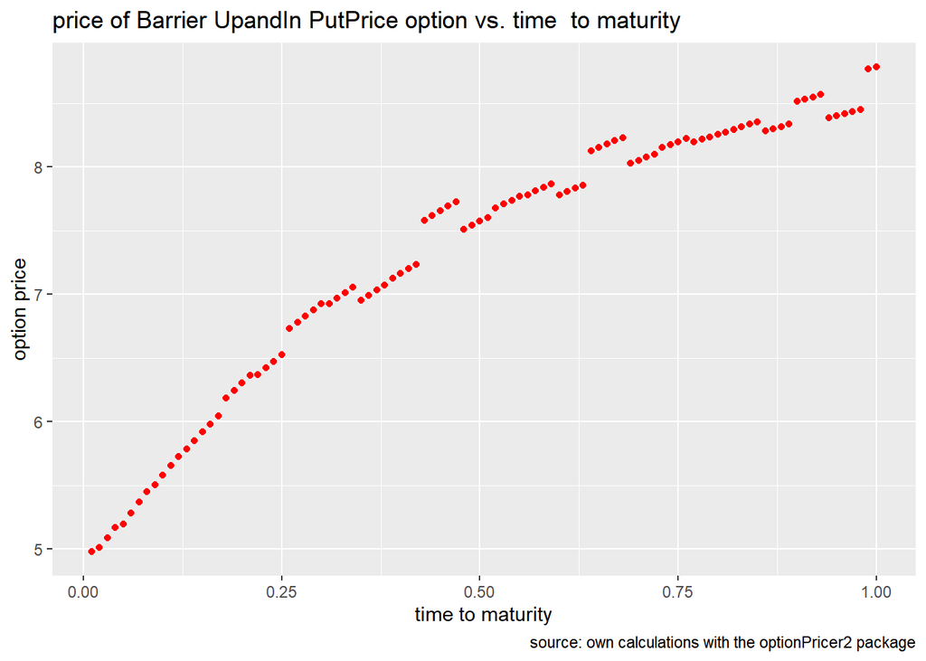

```r
tibble( expiry, prices) %>%
  ggplot(aes(expiry, prices)) +
  geom_point(col = "red") +
  labs(
    x     = "time to maturity",
    y     = "option price",
    title = "price of Barrier UpandIn PutPrice option vs. time  to maturity",
    caption = "source: own calculations with the optionPricer2 package")
```

## Part3:relation between the theoretical price of the option and volatility of the underlying instrument returns

build an R wrapping function: option price vs. volatility

```r
getMCBarrierUpandInPutPriceWithvolatility <- function (volatility) {
  return(
    myoptionPricer2::getBarrierUpandInPutPrice(105, 126, 105, 100, volatility, 0.05, 0.5,10000)
    )
}
```

call the wrapping function

```r
getMCBarrierUpandInPutPriceWithvolatility(0.2)
```

```
## [1] 7.008497
```

arguments values of values of function

```r
volatility  <- seq(0.01, 1, by = 0.01)
prices <- sapply(volatility, getMCBarrierUpandInPutPriceWithvolatility)
```

visualization: options price vs. volatility

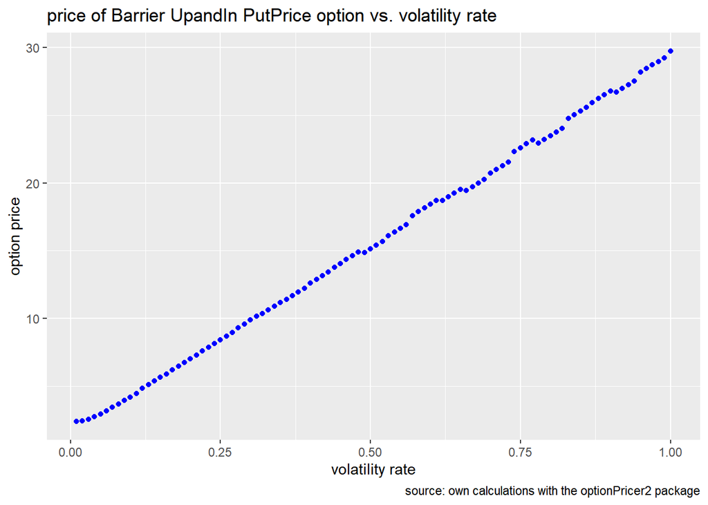

```r
tibble(volatility, prices) %>%
  ggplot(aes(volatility, prices)) +
  geom_point(col = "blue") +
  labs(
    x     = "volatility rate",
    y     = "option price",
    title = "price of Barrier UpandIn PutPrice option vs. volatility rate",
    caption = "source: own calculations with the optionPricer2 package")
```

## Part4:option price vs. number of loops

build an R wrapping function: option price vs. number of loops

```r
getBarrierUpandInPutPriceLoops <- function (loops) {
  return(
    myoptionPricer2::getBarrierUpandInPutPrice(105, 126, 105, 100, 0.22, 0.05, 0.5,loops)
  )
}
```

call the wrapping function

```r
getBarrierUpandInPutPriceLoops(500)
```

```
## [1] 7.483167
```

arguments values of values of function

```r
loops  <- seq(100, 10000, by = 100)
prices <- sapply(loops, getBarrierUpandInPutPriceLoops)
```

visualization: options price vs. numbers of loops

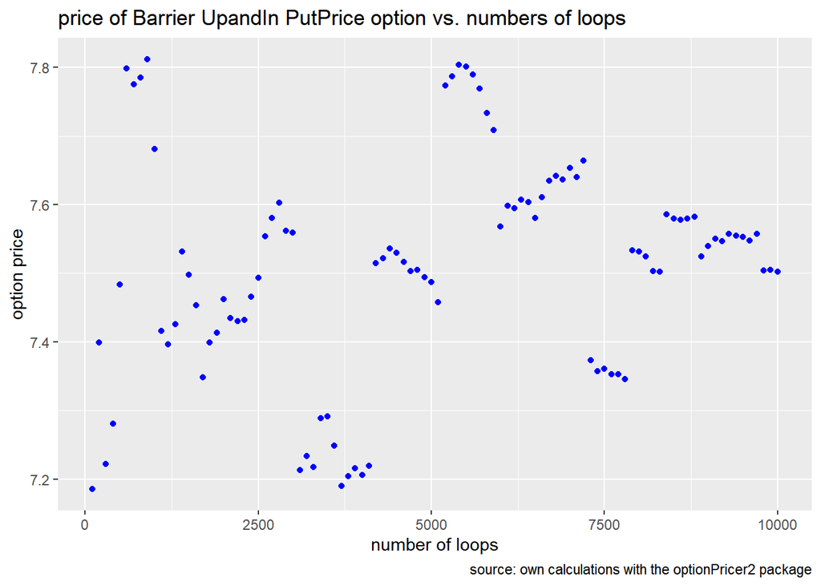

```r
tibble(loops, prices) %>%
  ggplot(aes(loops, prices)) +
  geom_point(col = "blue") +
  labs(
    x     = "number of loops",
    y     = "option price",
    title = "price of Barrier UpandIn PutPrice option vs. numbers of loops ",
    caption = "source: own calculations with the optionPricer2 package")
```